# Lab04_DeepLearning_iNaturalist

Julia Parish

2022/03/02

# Deep Learning - iNaturalist

Homework task is to apply deep learning skills to build the following models:

- 2 Species (binary classification) - neural net. Draw from 3.4 🍿 Movies (binary classification). You’ll need to pre-process the images to be a consistent shape first though – see 5.2.4 Data preprocessing.
- 2 Species (binary classification) - convolutional neural net. Draw from the dogs vs cats example.
- 10 Species (multi-class classification) - neural net. Draw from 3.5 📰 Newswires (multi-class classification).
- 10 Species (multi-class classification) - convolutional neural net. Draw from dogs vs cats example and update necessary values to go from binary to mult-class classification.

In the models, be sure to include the following:

- Split the original images per species (n=50) into train (n=30), validate (n=10) and test (n=10). These are almost absurdly few files to feed into these complex deep learning models but will serve as a good learning example.
- Include accuracy metric and validation in the fitting process and history plot.
- Evaluate loss and accuracy on your test model results. Compare standard neural network and convolutional neural network results.

```r
librarian::shelf(
  digest, dplyr, DT, keras, glue, here, readr, tensorflow, tidyverse)
```

```
##
##   The 'cran_repo' argument in shelf() was not set, so it will use
##   cran_repo = 'https://cran.r-project.org' by default.
##
##   To avoid this message, set the 'cran_repo' argument to a CRAN
##   mirror URL (see https://cran.r-project.org/mirrors.html) or set
##   'quiet = TRUE'.
```

```r
# path to folder containing species directories of images
dir_src  <- "/courses/EDS232/inaturalist-2021/train_mini"
dir_dest <- here("inat/")
dir.create(dir_dest, showWarnings = F)

# get list of directories, one per species (n = 10,000 species)
dirs_spp <- list.dirs(dir_src, recursive = F, full.names = T)
n_spp <- length(dirs_spp)

# set seed (for reproducible results)
# just before sampling (otherwise get different results)
# based on your username (unique amongst class)
Sys.info()[["user"]] %>%
  digest::digest2int() %>%
  set.seed()
i10 <- sample(1:n_spp, 10)

# show the 10 indices sampled of the 10,000 possible
i10
```

```
##  [1] 3651 6904 6267 8184 8185 9711 1135 6279 1569 6958
```

```r
# show the 10 species directory names
basename(dirs_spp)[i10]
```

```
##  [1] "03650_Animalia_Chordata_Aves_Gruiformes_Gruidae_Grus_americana"
##  [2] "06903_Plantae_Tracheophyta_Magnoliopsida_Asterales_Asteraceae_Nabalus_trifoliolatus"
##  [3] "06266_Plantae_Tracheophyta_Liliopsida_Poales_Cyperaceae_Carex_sprengelii"
##  [4] "08183_Plantae_Tracheophyta_Magnoliopsida_Fagales_Fagaceae_Quercus_garryana"
##  [5] "08184_Plantae_Tracheophyta_Magnoliopsida_Fagales_Fagaceae_Quercus_geminata"
##  [6] "09710_Plantae_Tracheophyta_Magnoliopsida_Solanales_Hydroleaceae_Hydrolea_ovata"
##  [7] "01134_Animalia_Arthropoda_Insecta_Lepidoptera_Erebidae_Utetheisa_pulchella"
##  [8] "06278_Plantae_Tracheophyta_Liliopsida_Poales_Cyperaceae_Cyperus_esculentus"
##  [9] "01568_Animalia_Arthropoda_Insecta_Lepidoptera_Noctuidae_Agrotis_puta"
## [10] "06957_Plantae_Tracheophyta_Magnoliopsida_Asterales_Asteraceae_Pyrrhopappus_pauciflorus"
```

```r
# show the first 2 species directory names
i2 <- i10[1:2]
basename(dirs_spp)[i2]
```

```
## [1] "03650_Animalia_Chordata_Aves_Gruiformes_Gruidae_Grus_americana"
## [2] "06903_Plantae_Tracheophyta_Magnoliopsida_Asterales_Asteraceae_Nabalus_trifoliolatus"
```

### Split the original images per species (n=50) into train (n=30), validate (n=10) and test (n=10)

```r
# setup data frame with source (src) and destination (dest) paths to images
d <- tibble(
  set     = c(rep("spp2", 2), rep("spp10", 10)),
  dir_sp  = c(dirs_spp[i2], dirs_spp[i10]),
  tbl_img = map(dir_sp, function(dir_sp){
    tibble(
      src_img = list.files(dir_sp, full.names = T),
      subset  = c(rep("train", 30), rep("validation", 10), rep("test", 10))) })) %>%
  unnest(tbl_img) %>%
  mutate(
    sp       = basename(dir_sp),
    img      = basename(src_img),
    dest_img = glue("{dir_dest}/{set}/{subset}/{sp}/{img}"))

# show source and destination for first 10 rows of tibble
d %>%
  select(src_img, dest_img)
```

```
## # A tibble: 600 × 2
##    src_img                                dest_img
##    <chr>                                  <glue>
##  1 /courses/EDS232/inaturalist-2021/trai… /Users/jparish/EDS232_MachineLearning…
##  2 /courses/EDS232/inaturalist-2021/trai… /Users/jparish/EDS232_MachineLearning…
##  3 /courses/EDS232/inaturalist-2021/trai… /Users/jparish/EDS232_MachineLearning…
##  4 /courses/EDS232/inaturalist-2021/trai… /Users/jparish/EDS232_MachineLearning…
##  5 /courses/EDS232/inaturalist-2021/trai… /Users/jparish/EDS232_MachineLearning…
##  6 /courses/EDS232/inaturalist-2021/trai… /Users/jparish/EDS232_MachineLearning…
##  7 /courses/EDS232/inaturalist-2021/trai… /Users/jparish/EDS232_MachineLearning…
##  8 /courses/EDS232/inaturalist-2021/trai… /Users/jparish/EDS232_MachineLearning…
##  9 /courses/EDS232/inaturalist-2021/trai… /Users/jparish/EDS232_MachineLearning…
## 10 /courses/EDS232/inaturalist-2021/trai… /Users/jparish/EDS232_MachineLearning…
## # … with 590 more rows
```

```r
# iterate over rows, creating directory if needed and copying files
d %>%
  pwalk(function(src_img, dest_img, ...){
    dir.create(dirname(dest_img), recursive = T, showWarnings = F)
    file.copy(src_img, dest_img) })

# uncomment to show the entire tree of your destination directory
# system(glue("tree {dir_dest}"))
```

# 1. 2 Species (binary classification) - neural net

```r
train_dir_2spp <- here("inat/spp2/train")
test_dir_2spp <- here("inat/spp2/test")
validation_dir_2spp <- here("inat/spp2/validation")

# All images will be rescaled by 1/255
train_datagen_2spp <- image_data_generator(rescale = 1/255)
```

```
## Loaded Tensorflow version 2.7.1
```

```r
test_datagen_2spp <- image_data_generator(rescale = 1/255)
validation_datagen_2spp <- image_data_generator(rescale = 1/255)

train_generator_2spp <- flow_images_from_directory(
  train_dir_2spp,  # This is the target directory
  train_datagen_2spp, # This is the data generator
  target_size = c(150, 150), # All images will be resized to 150x150
  batch_size = 5,
  # Since we use binary_crossentropy loss, we need binary labels
  class_mode = "binary")

test_generator_2spp <- flow_images_from_directory(
  test_dir_2spp,
  test_datagen_2spp,
  target_size = c(150, 150),
  batch_size = 5,
  class_mode = "binary")

validation_generator_2spp <- flow_images_from_directory(
  validation_dir_2spp,
  validation_datagen_2spp,
  target_size = c(150, 150),
  batch_size = 5,
  class_mode = "binary")
```

```r
# The intermediate layers will use relu as their “activation function”, and the final layer will use a sigmoid activation so as to output a probability (a score between 0 and 1, indicating how likely the sample is to have the target “1”, i.e. how likely the review is to be positive). A relu (rectified linear unit) is a function meant to zero-out negative values, while a sigmoid “squashes” arbitrary values into the [0, 1] interval, thus outputting something that can be interpreted as a probability.

model_spp2 <- keras_model_sequential() %>%
  layer_dense(units = 16, activation = "relu", input_shape = c(150, 150, 3)) %>%
  layer_dense(units = 16, activation = "relu") %>%
  layer_flatten() %>%
  layer_dense(units =  1, activation = "sigmoid")
```

pick a loss function and an optimizer -

```r
# we configure our model with the rmsprop optimizer and the binary_crossentropy loss function. Note that we will also monitor accuracy during training.

model_spp2 %>% compile(
  optimizer = "rmsprop",
  loss      = "binary_crossentropy",
  metrics   = c("accuracy"))
```

```r
# to configure the parameters of your optimizer
model_spp2 %>% compile(
  optimizer = optimizer_rmsprop(learning_rate = 0.0001),
  loss      = "binary_crossentropy",
  metrics   = c("acc"))
```

```r
# pass a custom loss function or metric function

# model_spp2 %>% compile(
#   optimizer = optimizer_rmsprop(lr = 0.001),
#   loss      = loss_binary_crossentropy,
#   metrics   = metric_binary_accuracy)
```

```r
# train our model

history_spp2 <- model_spp2 %>% fit(
  train_generator_2spp,
  steps_per_epoch = 5,
  epochs = 10,
  validation_data = validation_generator_2spp,
  validation_steps = 1)

str(history_spp2)
```

```
## List of 2
##  $ params :List of 3
##   ..$ verbose: int 1
##   ..$ epochs : int 10
##   ..$ steps  : int 5
##  $ metrics:List of 4
##   ..$ loss    : num [1:10] 0.968 0.983 0.574 0.485 0.773 ...
##   ..$ acc     : num [1:10] 0.6 0.56 0.68 0.76 0.64 ...
##   ..$ val_loss: num [1:10] 0.584 0.444 0.558 0.88 0.549 ...
##   ..$ val_acc : num [1:10] 0.6 0.8 0.6 0.6 0.6 ...
##  - attr(*, "class")= chr "keras_training_history"
```

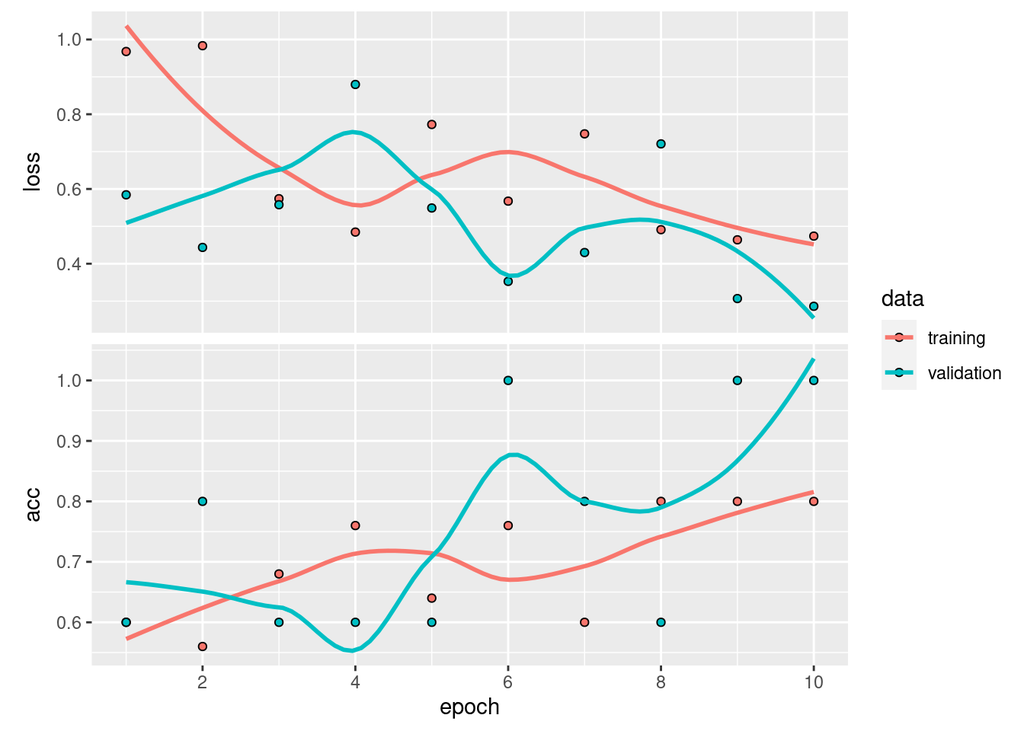

```r
plot(history_spp2)
```

```r
results_spp2 <- model_spp2 %>% evaluate(test_generator_2spp)
results_spp2
```

```
##      loss       acc
## 0.5093533 0.8000000
```

## 2. 2 Species (binary classification) - convolutional neural net

```r
cnn_model_spp2 <- keras_model_sequential() %>%
  layer_conv_2d(
    filters = 32, kernel_size = c(3, 3), activation = "relu",
    input_shape = c(150, 150, 3)) %>%
  layer_max_pooling_2d(pool_size = c(2, 2)) %>%
  layer_conv_2d(filters = 64, kernel_size = c(3, 3), activation = "relu") %>%
  layer_max_pooling_2d(pool_size = c(2, 2)) %>%
  layer_conv_2d(filters = 128, kernel_size = c(3, 3), activation = "relu") %>%
  layer_max_pooling_2d(pool_size = c(2, 2)) %>%
  layer_conv_2d(filters = 128, kernel_size = c(3, 3), activation = "relu") %>%
  layer_max_pooling_2d(pool_size = c(2, 2)) %>%
  layer_flatten() %>%
  layer_dropout(rate = 0.5) %>%
  layer_dense(units = 512, activation = "relu") %>%
  layer_dense(units = 1, activation = "sigmoid")

cnn_model_spp2 %>% compile(
  loss = "binary_crossentropy",
  optimizer = optimizer_rmsprop(learning_rate = 0.0001),
  metrics = c("acc"))
```

```r
summary(cnn_model_spp2)
```

```
## Model: "sequential_1"
## ________________________________________________________________________________
##  Layer (type)                       Output Shape                    Param #
## ================================================================================
##  conv2d_3 (Conv2D)                  (None, 148, 148, 32)            896
##
##  max_pooling2d_3 (MaxPooling2D)     (None, 74, 74, 32)              0
##
##  conv2d_2 (Conv2D)                  (None, 72, 72, 64)              18496
##
##  max_pooling2d_2 (MaxPooling2D)     (None, 36, 36, 64)              0
##
##  conv2d_1 (Conv2D)                  (None, 34, 34, 128)             73856
##
##  max_pooling2d_1 (MaxPooling2D)     (None, 17, 17, 128)             0
##
##  conv2d (Conv2D)                    (None, 15, 15, 128)             147584
##
##  max_pooling2d (MaxPooling2D)       (None, 7, 7, 128)               0
##
##  flatten_1 (Flatten)                (None, 6272)                    0
##
##  dropout (Dropout)                  (None, 6272)                    0
##
##  dense_4 (Dense)                    (None, 512)                     3211776
##
##  dense_3 (Dense)                    (None, 1)                       513
##
## ================================================================================
## Total params: 3,453,121
## Trainable params: 3,453,121
## Non-trainable params: 0
## ________________________________________________________________________________
```

#### Train Model

```r
# train our model

history_cnn_spp2 <- cnn_model_spp2 %>% fit(
  train_generator_2spp,
  steps_per_epoch = 5,
  epochs = 30,
  validation_data = validation_generator_2spp,
  validation_steps = 1)

str(history_cnn_spp2)
```

```
## List of 2
##  $ params :List of 3
##   ..$ verbose: int 1
##   ..$ epochs : int 30
##   ..$ steps  : int 5
##  $ metrics:List of 4
##   ..$ loss    : num [1:30] 0.729 0.69 0.668 0.645 0.678 ...
##   ..$ acc     : num [1:30] 0.52 0.64 0.64 0.76 0.56 ...
##   ..$ val_loss: num [1:30] 0.689 0.668 0.685 0.598 0.626 ...
##   ..$ val_acc : num [1:30] 0.6 0.8 0.4 0.8 0.6 ...
##  - attr(*, "class")= chr "keras_training_history"
```

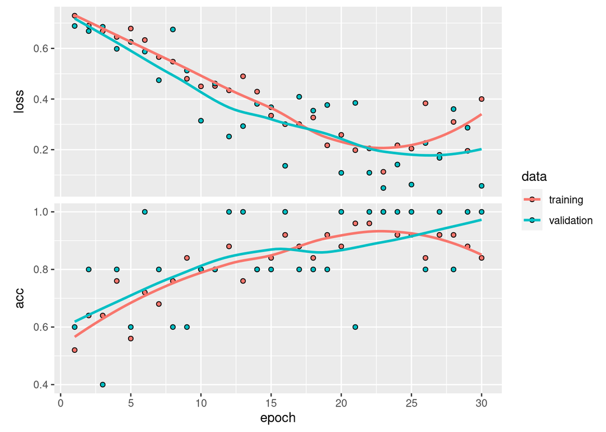

```r
plot(history_cnn_spp2)
```

```r
history_spp2
```

```
##
## Final epoch (plot to see history):
##     loss: 0.4739
##      acc: 0.8
## val_loss: 0.2861
##  val_acc: 1
```

```r
history_cnn_spp2
```

```
##
## Final epoch (plot to see history):
##     loss: 0.4
##      acc: 0.84
## val_loss: 0.0571
##  val_acc: 1
```

```r
results_spp2cnn <- cnn_model_spp2 %>% evaluate(test_generator_2spp)
results_spp2cnn
```

```
##      loss       acc
## 0.1814838 0.9000000
```

# 3 10 Species (multi-class classification) - neural net.

```r
train_dir_10spp <- here("inat/spp10/train")
test_dir_10spp <- here("inat/spp10/test")
validation_dir_10spp <- here("inat/spp10/validation")

# All images will be rescaled by 1/255
train_datagen_10spp <- image_data_generator(rescale = 1/255)
test_datagen_10spp <- image_data_generator(rescale = 1/255)
validation_datagen_10spp <- image_data_generator(rescale = 1/255)

train_generator_10spp <- flow_images_from_directory(
  train_dir_10spp,  # This is the target directory
  train_datagen_10spp, # This is the data generator
  target_size = c(150, 150), # All images will be resized to 150x150
  batch_size = 5,
  #
  class_mode = "categorical")

test_generator_10spp <- flow_images_from_directory(
  test_dir_10spp,
  test_datagen_10spp,
  target_size = c(150, 150),
  batch_size = 5,
  class_mode = "categorical")

validation_generator_10spp <- flow_images_from_directory(
  validation_dir_10spp,
  validation_datagen_10spp,
  target_size = c(150, 150),
  batch_size = 5,
  class_mode = "categorical")
```

```r
model_10spp <- keras_model_sequential() %>%
  layer_dense(units = 64, activation = "relu", input_shape = c(150, 150, 3)) %>%
  layer_dense(units = 64, activation = "relu") %>%
  layer_flatten() %>%
  layer_dense(units =  10, activation = "softmax")
```

```r
# to configure the parameters of your optimizer
model_10spp %>% compile(
  optimizer = optimizer_rmsprop(learning_rate = 0.0001),
  loss      = "categorical_crossentropy",
  metrics   = c("acc"))
```

```r
# train our model

history_10spp <- model_10spp %>% fit(
  train_generator_10spp,
  steps_per_epoch = 5,
  epochs = 30,
  validation_data = validation_generator_10spp,
  validation_steps = 1)
```

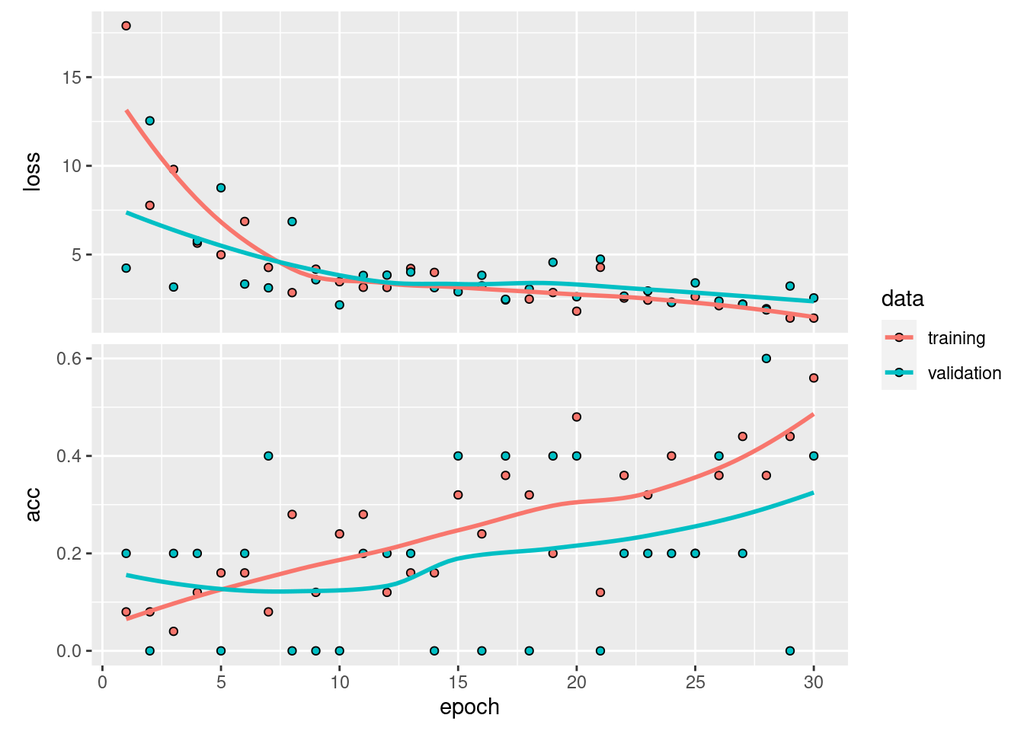

```r
plot(history_10spp)
```

```r
results_10spp <- model_10spp %>% evaluate(test_generator_10spp)
results_10spp
```

```
##     loss      acc
## 3.243466 0.200000
```

```r
history_10spp
```

```
##
## Final epoch (plot to see history):
##     loss: 1.416
##      acc: 0.56
## val_loss: 2.555
##  val_acc: 0.4
```

# 4. 10 Species (multi-class classification) - convolutional neural net

```r
cnn_model_10spp <- keras_model_sequential() %>%
  layer_conv_2d(
    filters = 32, kernel_size = c(3, 3), activation = "relu",
    input_shape = c(150, 150, 3)) %>%
  layer_max_pooling_2d(pool_size = c(2, 2)) %>%
  layer_conv_2d(filters = 64, kernel_size = c(3, 3), activation = "relu") %>%
  layer_max_pooling_2d(pool_size = c(2, 2)) %>%
  layer_conv_2d(filters = 128, kernel_size = c(3, 3), activation = "relu") %>%
  layer_max_pooling_2d(pool_size = c(2, 2)) %>%
  layer_conv_2d(filters = 128, kernel_size = c(3, 3), activation = "relu") %>%
  layer_max_pooling_2d(pool_size = c(2, 2)) %>%
  layer_flatten() %>%
  layer_dropout(rate = 0.5) %>%
  layer_dense(units = 512, activation = "relu") %>%
  layer_dense(units = 10, activation = "softmax")
```

```r
cnn_model_10spp %>% compile(
  loss = "categorical_crossentropy",
  optimizer = optimizer_rmsprop(learning_rate = 0.0001),
  metrics = c("acc"))
```

```r
history_cnn_10spp <- cnn_model_10spp %>% fit(
  train_generator_10spp,
  steps_per_epoch = 5,
  epochs = 30,
  validation_data = validation_generator_10spp,
  validation_steps = 10)
```

```r
history_cnn_10spp
```

```
##
## Final epoch (plot to see history):
##     loss: 2.077
##      acc: 0.28
## val_loss: 2.077
##  val_acc: 0.28
```

```r
results_10sppcnn <- cnn_model_10spp %>% evaluate(test_generator_10spp)
results_10spp
```

```
##     loss      acc
## 3.243466 0.200000
```

## Standard neural net compared to convolutional neural net

```r
results_10spp
```

```
##     loss      acc
## 3.243466 0.200000
```

```r
results_10sppcnn
```

```
##     loss      acc
## 2.087478 0.230000
```